# Regressao linear na pratica

## Dados da CAPES sobre avaliacao da pos-graduacao

A CAPES e um orgao do MEC que tem a atribuicao de acompanhar a pos-graduacao na universidade brasileira. Uma das formas que ela encontrou de fazer isso e pela qual ela e bastante criticada atraves de uma avaliacao quantitativa a cada x anos (era 3, mudou para 4).

Usaremos dados da penultima avaliacao da CAPES:

```r
library(tidyverse)
library(broom)
library(modelr)
source(here::here("/code/lib.R"))
options(encoding = 'UTF-8')
theme_set(theme_report())

knitr::opts_chunk$set(tidy = FALSE,
                      fig.width = 6,
                      fig.height = 5)

paleta = c("#404E4D",
           "#92DCE5",
           "#938BA1",
           "#2D3142",
           "#F4743B")
```

```r
cacc = read_projectdata()

glimpse(cacc)
```

```
## Observations: 73
## Variables: 31
## $ Instituicao                  <chr> "UNIVERSIDADE FEDERAL DO AMAZONAS...
## $ Programa                     <chr> "INFORMATICA (12001015012P2)", "C...
## $ Nivel                        <int> 5, 4, 3, 3, 3, 5, 4, 3, 3, NA, 5,...
## $ Sigla                        <chr> "UFAM", "UFPA", "UFMA", "UEMA", "...
## $ `Tem doutorado`              <chr> "Sim", "Sim", "N\xe3o", "N\xe3o",...
## $ `Docentes colaboradores`     <dbl> 0.25, 5.50, 3.00, 6.25, 1.75, 2.0...
## $ `Docentes permanentes`       <dbl> 24.75, 14.00, 10.00, 14.00, 9.50,...
## $ `Docentes visitantes`        <dbl> 0.00, 0.00, 0.00, 0.00, 0.00, 0.7...
## $ `Resumos em conf`            <int> 20, 23, 15, 5, 4, 10, 6, 136, 0, ...
## $ `Resumos expandidos em conf` <int> 25, 24, 7, 10, 1, 68, 9, 13, 4, 2...
## $ `Artigos em conf`            <int> 390, 284, 115, 73, 150, 269, 179,...
## $ Dissertacoes                 <int> 108, 77, 50, 25, 31, 75, 60, 129,...
## $ Teses                        <int> 14, 0, 0, 0, 0, 24, 5, 0, 0, 3, 2...
```

[output cut: 18 more lines]

### Producao e produtividade de artigos

Uma das maneiras de avaliar a producao dos docentes que a CAPES utiliza e quantificando a producao de artigos pelos docentes. Os artigos sao categorizados em extratos ordenados (A1 e o mais alto), e separados entre artigos em conferencias e periodicos. Usaremos para esse lab a producao em periodicos avaliados com A1, A2 e B1.

```r
cacc = cacc %>%
  mutate(producao = (periodicos_A1 + periodicos_A2 + periodicos_B1),
         produtividade = producao / `Docentes permanentes`,
         mestrados = Dissertacoes,
         doutorados = Teses,
         mestrados_pprof = mestrados / `Docentes permanentes`,
         doutorados_pprof = doutorados / `Docentes permanentes`)
```

### EDA

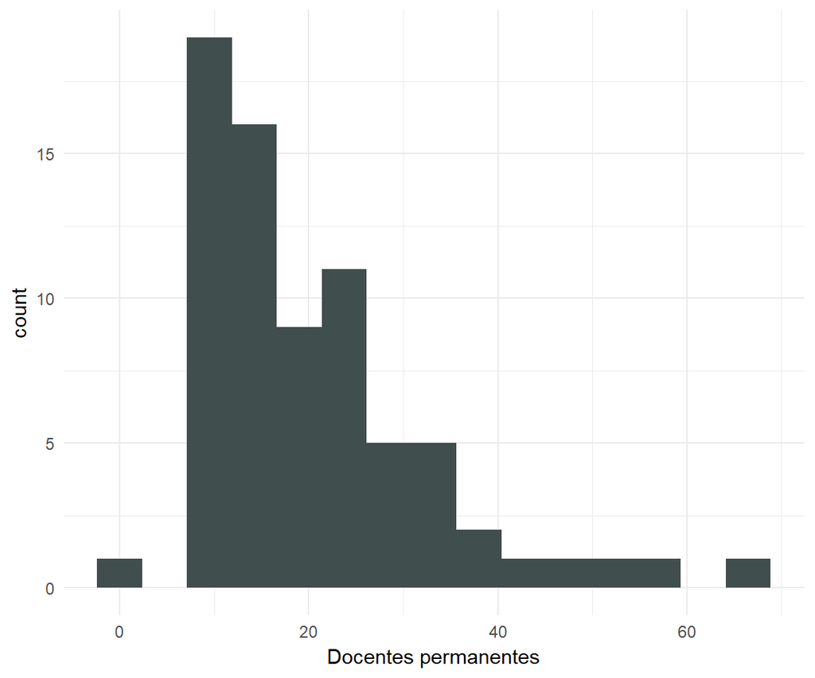

```r
cacc %>%
  ggplot(aes(x = `Docentes permanentes`)) +
  geom_histogram(bins = 15, fill = paleta[1])
```

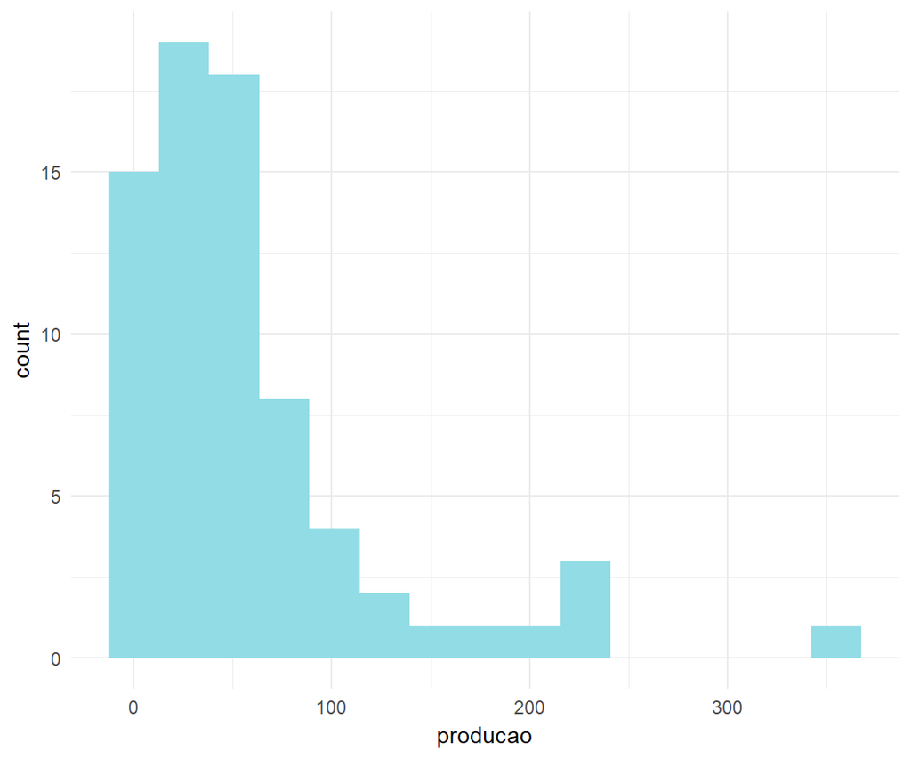

```r
cacc %>%
  ggplot(aes(x = producao)) +
  geom_histogram(bins = 15, fill = paleta[2])
```

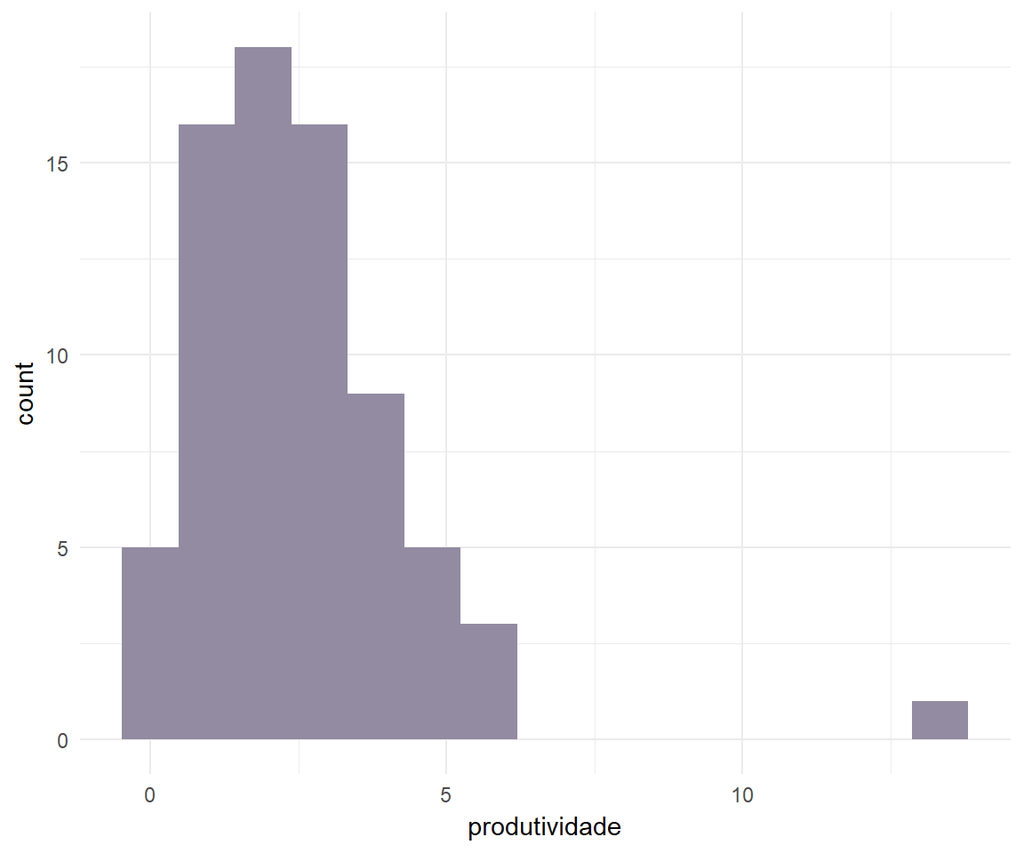

```r
cacc %>%
  ggplot(aes(x = produtividade)) +
  geom_histogram(bins = 15, fill = paleta[3])
```

Se quisermos modelar o efeito do tamanho do programa em termos de docentes (permanentes) na quantidade de artigos publicados, podemos usar regressao.

*Importante*: sempre queremos ver os dados antes de fazermos qualquer modelo ou sumario:

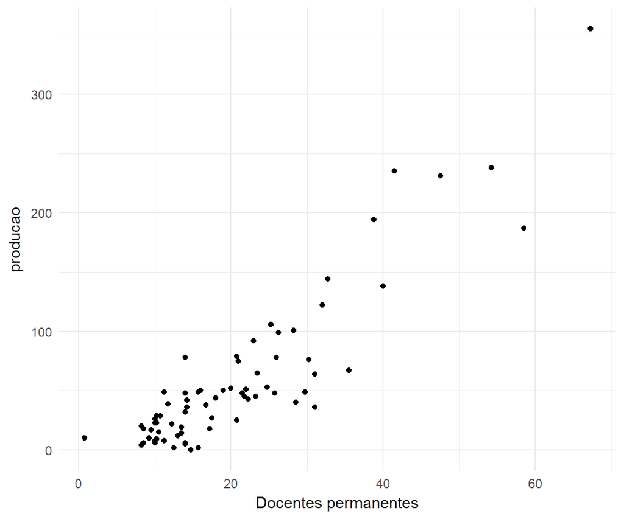

```r
cacc %>%
  ggplot(aes(x = `Docentes permanentes`, y = producao)) +
  geom_point()
```

Parece que existe uma relacao. Vamos criar um modelo entao:

```r
modelo1 = lm(producao ~ `Docentes permanentes`, data = cacc)

tidy(modelo1, conf.int = TRUE, conf.level = 0.95)
```

```
##                     term   estimate std.error statistic      p.value
## 1            (Intercept) -39.296664 6.5618387 -5.988667 7.887096e-08
## 2 `Docentes permanentes`   4.740882 0.2741282 17.294397 3.665525e-27
##     conf.low  conf.high
## 1 -52.380598 -26.212729
## 2   4.194286   5.287478
```

```r
glance(modelo1)
```

```
##   r.squared adj.r.squared    sigma statistic      p.value df    logLik
## 1  0.808158      0.805456 28.87914  299.0962 3.665525e-27  2 -348.0763
##        AIC      BIC deviance df.residual
## 1 702.1526 709.0239 59214.34          71
```

Para visualizar o modelo:

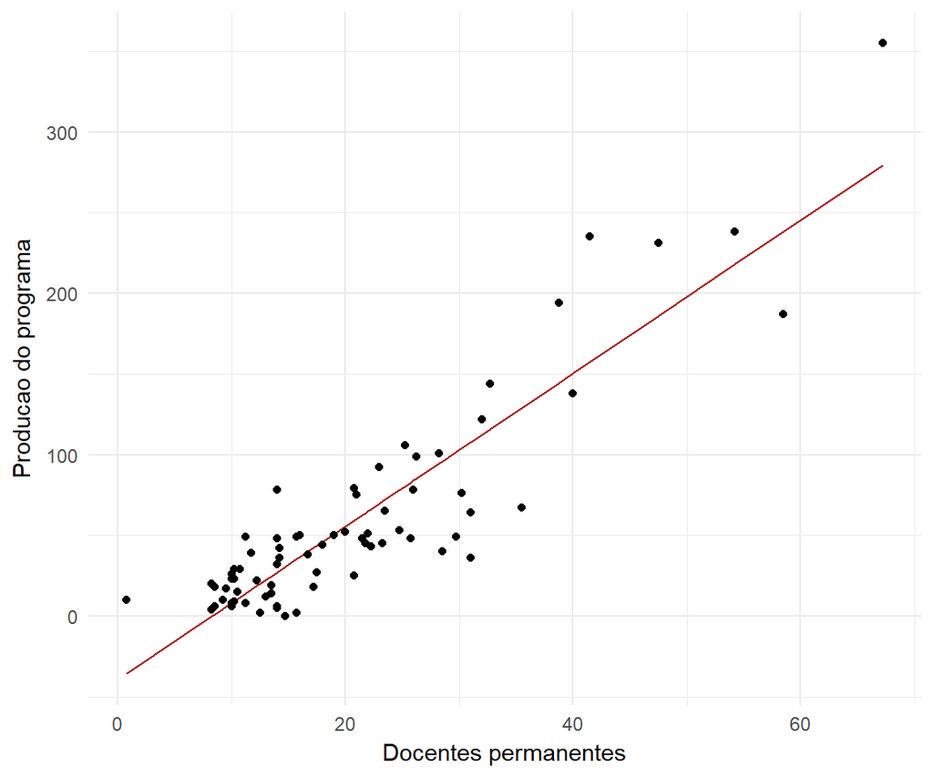

```r
cacc_augmented = cacc %>%
  add_predictions(modelo1)

cacc_augmented %>%
  ggplot(aes(x = `Docentes permanentes`)) +
  geom_line(aes(y = pred), colour = "brown") +
  geom_point(aes(y = producao)) +
  labs(y = "Producao do programa")
```

*Se considerarmos que temos apenas uma amostra de todos os programas de pos em CC no Brasil, o que podemos inferir a partir desse modelo sobre a relacaoo entre numero de docentes permanentes e producao de artigos em programas de pos?*

A Regressao linear foi utilizada para analisar se quantidade de docentes permanentes tem uma associacao significativa com producao do programa de pos graduacao, definido pela quantidade de artigos publicados em periodicos com qualis A1, A2 e B1. Os resultados da regressao indicam que um modelo com 1 preditor, apresentando docentes permanentes (x) como a variavel independente e a producao do programa (y) como a variavel dependente, no formato:
$$y = -39.29 + 4.74 \cdot x,$$
explica $80.81%$ da variancia da variavel de resposta ($R^2 = 0.8081$). A variavel $x$ (quantidade de docentes permanentes), tem uma relacao significativa com o erro ($b = [4.19; 5.29]$, IC com $95%$). O aumento de 1 unidade de $x$ produz uma mudanca de mais ou menos $4.74$ em $y$, que pode ser verificado na associacao do valor estimado para a variavel Docentes permanentes.

*Dito isso, o que significa a relacao que voce encontrou na pratica para entendermos os programas de pos graduacao no Brasil? E algum palpite de por que a relacao que encontramos e forte?*

A relacao entre as variaveis mostra que producao bem avaliada e quantidade de docentes permamentes em programas de pos graduacao pode ser explicada em mais de 80%. Podemos concluir que o resultado esta fortemente ligado, existe uma relacao fiel entre as variaveis. Essa relevancia todo se da por conta que na publicacao de um artigo constar o nome do orientador e no caso esse ser docente permanente (O programa e voltado para ter como orientadores professores permanentes na instituicao).

## Mais fatores

E se considerarmos tambem o numero de alunos?

```r
modelo2 = lm(producao ~ `Docentes permanentes` + mestrados + doutorados, data = cacc)

tidy(modelo2, conf.int = TRUE, conf.level = 0.95)
```

```
##                     term    estimate  std.error statistic      p.value
## 1            (Intercept) -11.6427810 7.46446111 -1.559762 1.233914e-01
## 2 `Docentes permanentes`   3.2818882 0.44134079  7.436177 2.142517e-10
## 3              mestrados  -0.1703142 0.08128627 -2.095239 3.982187e-02
## 4             doutorados   1.0264670 0.18609070  5.515950 5.645833e-07
##      conf.low    conf.high
## 1 -26.5339735  3.248411436
## 2   2.4014374  4.162339007
## 3  -0.3324759 -0.008152518
## 4   0.6552262  1.397707757
```

```r
glance(modelo2)
```

```
##   r.squared adj.r.squared   sigma statistic      p.value df    logLik
## 1 0.8670713     0.8612918 24.3852  150.0251 3.637862e-30  4 -334.6859
##        AIC      BIC deviance df.residual
## 1 679.3718 690.8241 41030.02          69
```

Visualizar o modelo com muitas variaveis independentes fica mais dificil

```r
para_plotar_modelo = cacc %>%
  data_grid(producao = seq_range(producao, 10), # Crie um vetor de 10 valores no range
            `Docentes permanentes` = seq_range(`Docentes permanentes`, 4),
            # mestrados = seq_range(mestrados, 3),
            mestrados = median(mestrados),
            doutorados = seq_range(doutorados, 3)) %>%
  add_predictions(modelo2)

glimpse(para_plotar_modelo)
```

```
## Observations: 120
## Variables: 5
## $ producao               <dbl> 0.00000, 0.00000, 0.00000, 0.00000, 0.0...
## $ `Docentes permanentes` <dbl> 0.75000, 0.75000, 0.75000, 22.91667, 22...
## $ mestrados              <int> 60, 60, 60, 60, 60, 60, 60, 60, 60, 60,...
## $ doutorados             <dbl> 0, 76, 152, 0, 76, 152, 0, 76, 152, 0, ...
## $ pred                   <dbl> -19.40022, 58.61127, 136.62276, 53.3483...
```

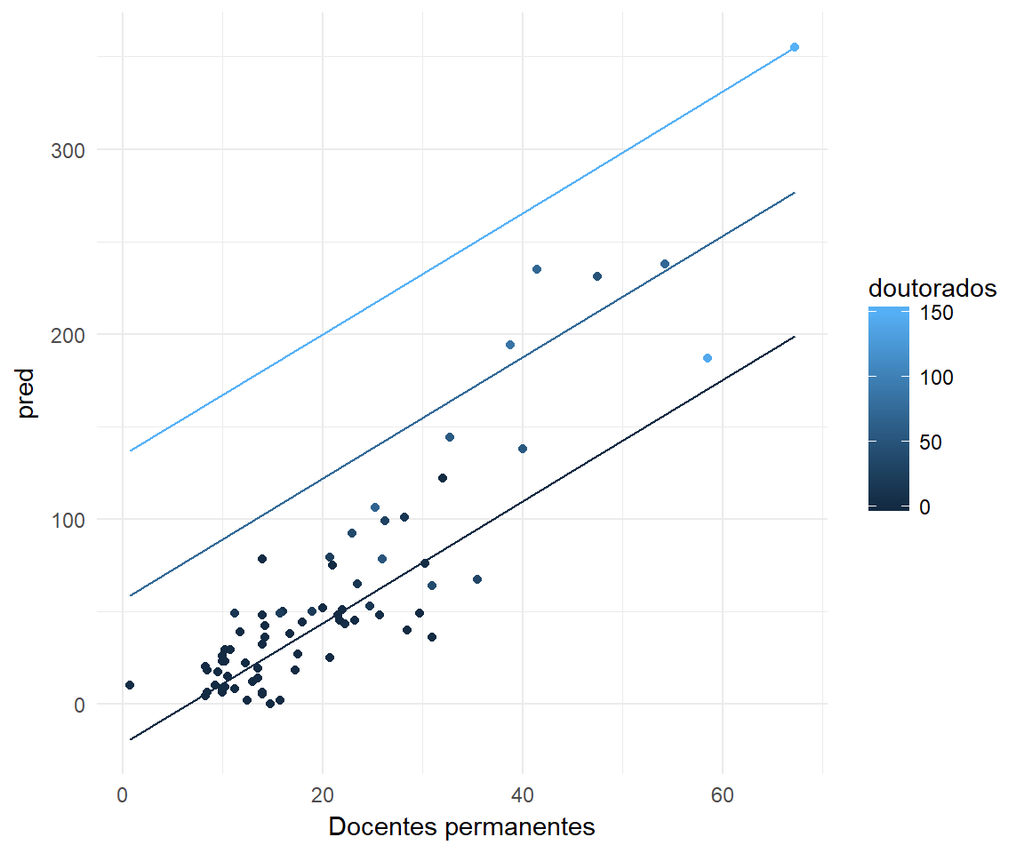

```r
para_plotar_modelo %>%
  ggplot(aes(x = `Docentes permanentes`, y = pred)) +
  geom_line(aes(group = doutorados, colour = doutorados)) +
  # facet_grid(. ~ as.factor(mestrados)) +
  geom_point(data = cacc, aes(y = producao, colour = doutorados))
```

Considerando agora esses tres fatores, o que podemos dizer sobre como cada um deles se relaciona com a producao de um programa de pos em CC? E sobre o modelo? Ele explica mais que o modelo 1?

A Regressao multipla foi utilizada para analisar se quantidade de docentes permanentes, numero de alunos de mestrado e numero de alunos de doutorado tem uma associacao significativa com producao do programa de pos graduacao. Os resultados da regressao indicam que um modelo com os 3 preditores, sendo docentes permanentes ($x$), alunos de mestrado ($z$) e alunos de doutorado ($w$) como variaveis independentes e a quantidade de producao no programa ($y$) como a variavel dependente, no formato:
$$y = -11.64 + 3.28 \cdot x - 0.17 \cdot z + 1.026 \cdot w,$$
explicam $86.70%$ da variancia da variavel de resposta ($R^2 = 0.8670$). A variavel $x$ (quantidade de docentes permanentes), tem uma forte relacao com o erro $([2.4; 4.16]$, IC com $95%$). A a variavel $w$ (quantidade de alunos de doutorado), tem uma forte relacao com o erro ($[0.66; 1.397]$, IC com $95%$). A variavel $z$ (quantidade de alunos de menstrado), apresentou uma relacao negativa, tem uma forte relacao com o erro ($[-0.33; -0.008]$, IC com $95%$).

## Agora produtividade

Diferente de medirmos producao (total produzido), e medirmos produtividade (produzido / utilizado). Abaixo focaremos nessa analise. Para isso crie um modelo que investiga como um conjunto de fatores que voce julga que sao relevantes se relacionam com a produtividade dos programas. Crie um modelo que avalie como pelo menos 3 fatores se relacionam com a produtividade de um programa. Pode reutilizar fatores que ja definimos e analizamos para producao. Mas cuidado para nao incluir fatores que sejam funcao linear de outros ja incluidos (ex: incluir A, B e um tercero C=A+B)

Produza abaixo o modelo e um texto que comente (i) o modelo, tal como os que fizemos antes, e (ii) as implicacoes - o que aprendemos sobre como funcionam programas de pos no brasil?

MODELO

```r
modelo_prev = lm(produtividade ~ Nivel + producao + doutorados, data = cacc)

tidy(modelo_prev, conf.int = TRUE, conf.level = 0.95)
```

```
##          term    estimate   std.error  statistic      p.value    conf.low
## 1 (Intercept)  0.07473060 0.491474515  0.1520539 8.795947e-01 -0.90599152
## 2       Nivel  0.38299495 0.152757623  2.5072068 1.456311e-02  0.07817186
## 3    producao  0.01970057 0.003305702  5.9595726 1.000407e-07  0.01310414
## 4  doutorados -0.02161102 0.006486551 -3.3316656 1.398648e-03 -0.03455473
##      conf.high
## 1  1.055452725
## 2  0.687818046
## 3  0.026296995
## 4 -0.008667307
```

```r
glance(modelo_prev)
```

```
##   r.squared adj.r.squared     sigma statistic      p.value df    logLik
## 1 0.6791607      0.665006 0.7979192  47.98136 9.028291e-17  4 -83.85202
##       AIC      BIC deviance df.residual
## 1 177.704 189.0874 43.29391          68
```

OBS: TIVE PROBLEMAS COM A CODIFICACAO DOS CARACTERES (ESPERO COMPREENSAO)